# STAT 302 SPR2020 Lecture 11

Sheridan Grant

May 4, 2020

## Preliminaries

```r
library(dplyr)
sat <- read.csv('../data/sat.csv')
colnames(sat)
```

```
## [1] "ï..sex" "SATV"   "SATM"   "SATSum" "HSGPA"  "FYGPA"
```

```r
colnames(sat)[1] <- 'sex'
sat$sex <- sat$sex - 1  # 0/1 is conventional, data gives 1/2
n <- dim(sat)[1]
```

## Polynomials

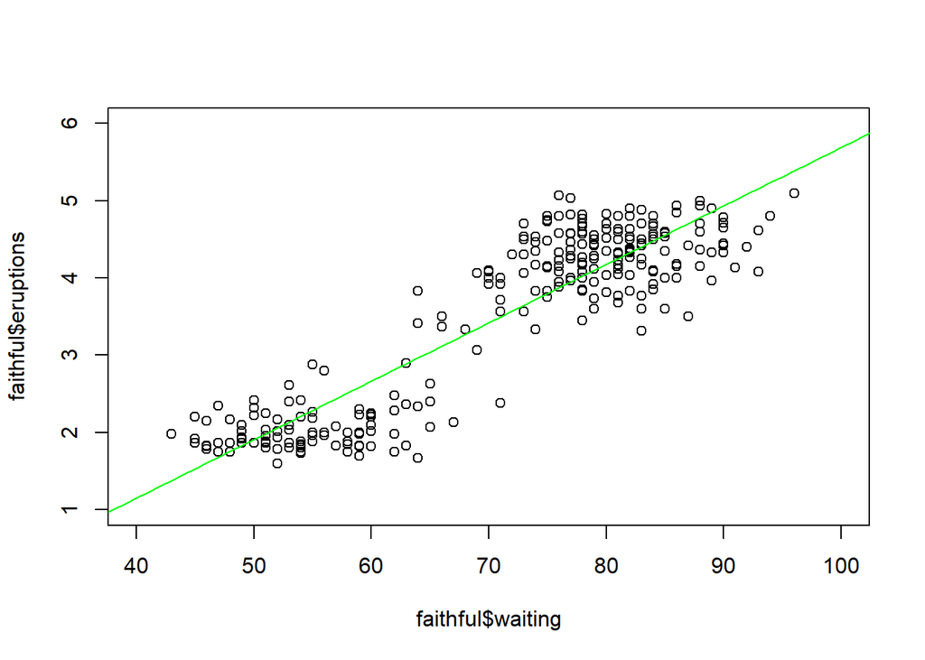

```r
plot(faithful$waiting, faithful$eruptions,
     xlim = c(40,100), ylim = c(1,6))
faithfulGrid <- data.frame(waiting = seq(35,105))
deg1 <- lm(eruptions ~ waiting, data = faithful)
lines(faithfulGrid$waiting, predict(deg1, faithfulGrid), col = 'green')
```

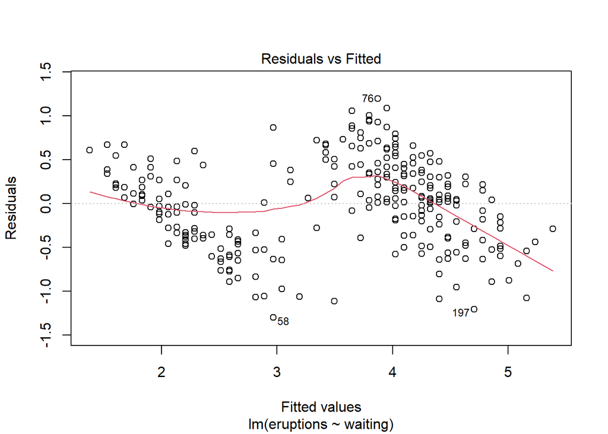

```r
plot(deg1, which = 1)
deg5 <- lm(eruptions ~ poly(waiting,5), data = faithful)
lines(faithfulGrid$waiting, predict(deg5, faithfulGrid), col = 'blue')
deg20 <- lm(eruptions ~ poly(waiting,20), data = faithful)
lines(faithfulGrid$waiting, predict(deg20, faithfulGrid), col = 'red')
```

```r
sigma(deg1)
```

```
## [1] 0.4965129
```

```r
sigma(deg5)
```

```
## [1] 0.3854619
```

```r
sigma(deg20)
```

```
## [1] 0.374464
```

Residual SE keeps decreasing–even df-corrected–though clearly the last model is ridiculous. Degree-5 more ambiguous. So even assessing model fit with model size (degrees of freedom) adjustment isn’t really enough.

(BTW, what model should you actually use?)

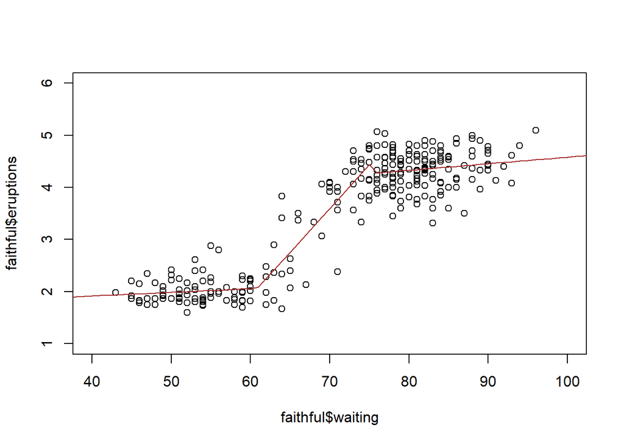

```r
faithful$phase <- factor((faithful$waiting > 60) + (faithful$waiting > 75))
faithfulGrid$phase <- factor((faithfulGrid$waiting > 60) + (faithfulGrid$waiting > 75))
piecewise <- lm(eruptions ~ waiting*phase, data = faithful)
plot(faithful$waiting, faithful$eruptions,
     xlim = c(40,100), ylim = c(1,6))
lines(faithfulGrid$waiting, predict(piecewise, faithfulGrid), col = 'brown')
```

```r
sigma(piecewise)
```

```
## [1] 0.3708942
```

This makes an ounce of sense, is slightly more complicated than basic linear model to respect the structure of the data, and has lower sigma than any of the polynomials.

## Prediction

Split the data into train (we train, or fit, the model to this data) and test (we test the model’s predictive power on these data):

```r
n <- dim(faithful)[1]
indices <- sample(n)
nTrain <- floor(1/2*n)
train <- faithful[indices[1:nTrain],]
test <- faithful[indices[(nTrain+1):n],]
```

Now we *train* (machine learning) or *fit* (statistics) the model on the training data, and *test* it on the test data:

```r
deg1t <- lm(eruptions ~ waiting, data = train)
deg5t <- lm(eruptions ~ poly(waiting,5), data = train)
deg20t <- lm(eruptions ~ poly(waiting,20), data = train)
piecewiseT <- lm(eruptions ~ waiting*phase, data = train)
sqrt(mean((test$eruptions - predict(deg1t, test))^2))
```

```
## [1] 0.4980709
```

```r
sqrt(mean((test$eruptions - predict(deg5t, test))^2))
```

```
## [1] 0.4060832
```

```r
sqrt(mean((test$eruptions - predict(deg20t, test))^2))
```

```
## [1] 5.223862
```

```r
sqrt(mean((test$eruptions - predict(piecewiseT, test))^2))
```

```
## [1] 0.3802609
```

RMSE

Whoa, that 20-degree error is wild! What happened? The 20-degree polynomial prediction line appears to fit the training data super well:

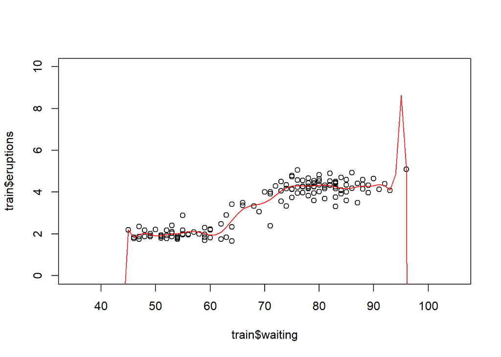

```r
plot(train$waiting, train$eruptions, xlim = c(35, 105), ylim = c(0,10))
lines(faithfulGrid$waiting, predict(deg20t, faithfulGrid), col = 'red')
```

But on the test data, it’s a different story. It’s possible that due to random splitting into train/test your test fit isn’t too bad, but probably there are some pretty bad predictions at points.

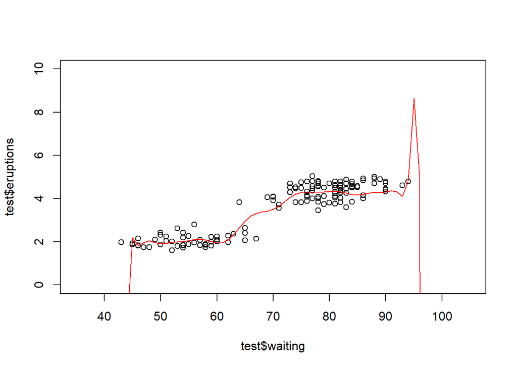

```r
plot(test$waiting, test$eruptions, xlim = c(35, 105), ylim = c(0,10))
lines(faithfulGrid$waiting, predict(deg20t, faithfulGrid), col = 'red')
```

Extrapolation gets way worse the more overfit the model is. Even for quintic:

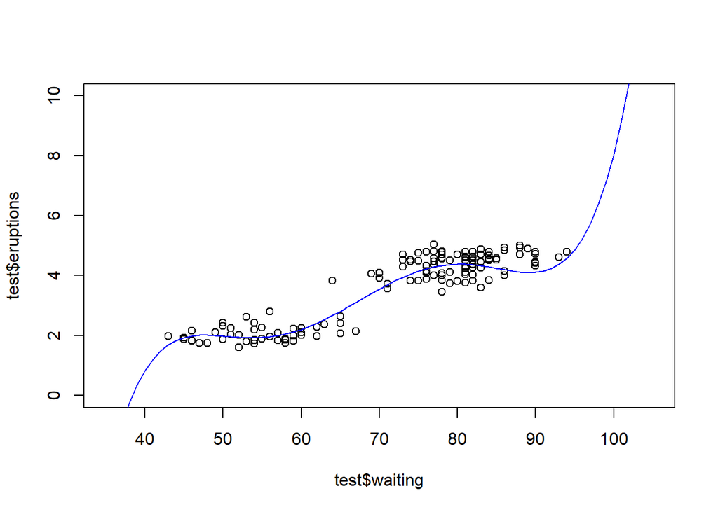

```r
plot(test$waiting, test$eruptions, xlim = c(35, 105), ylim = c(0,10))
lines(faithfulGrid$waiting, predict(deg5t, faithfulGrid), col = 'blue')
```

How about the piecewise?

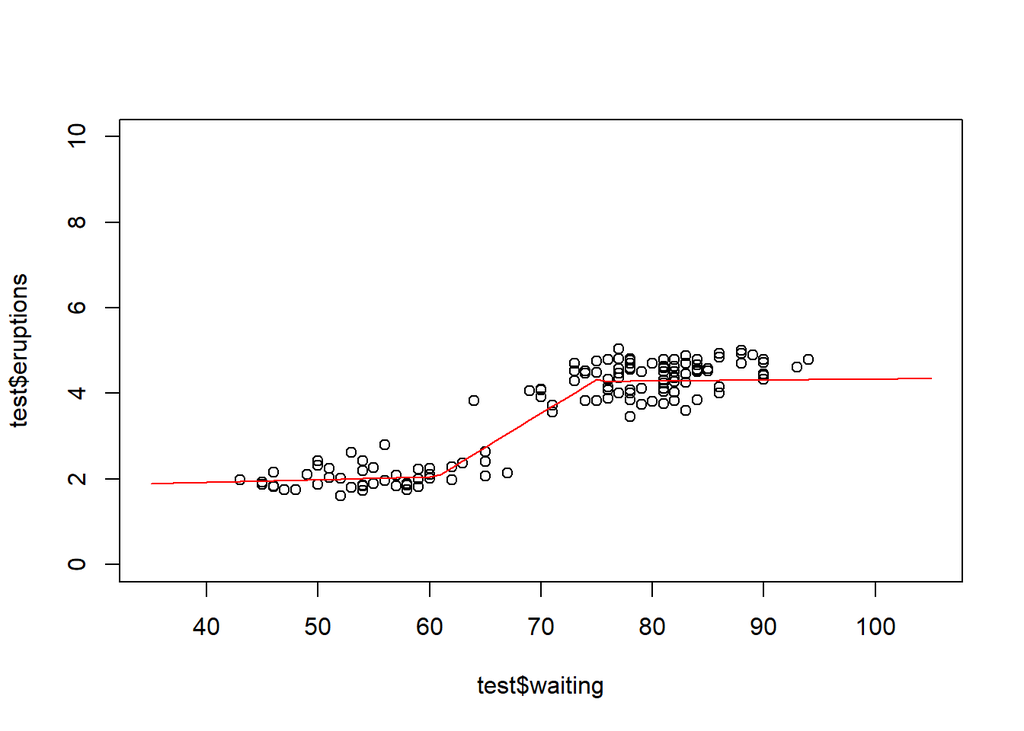

```r
plot(test$waiting, test$eruptions, xlim = c(35, 105), ylim = c(0,10))
lines(faithfulGrid$waiting, predict(piecewiseT, faithfulGrid), col = 'red')
```

## Extrapolation

In general, extrapolation is prediction on data points that come from a different distribution than the training data. You did a slight extrapolation at the end of HW 5 graded, and saw that even this extrapolation was difficult to get right. Let’s consider a more extreme example, for the SAT data:

```r
satTrain <- sat %>% filter(SATSum < 120,
                           SATSum > 80)
satTest <- sat %>% filter(SATSum > 140)
satMod <- lm(FYGPA ~ HSGPA, data = satTrain)
sigma(satMod)
```

```
## [1] 0.6166203
```

```r
sqrt(mean((satTest$FYGPA - predict(satMod, satTest))^2))
```

```
## [1] 0.6814573
```